# ESM 244: Palmetto Model

Kristina Fauss

2022-02-21

```r
knitr::opts_chunk$set(echo = TRUE,message=FALSE,warning = FALSE)
library(tidyverse)
library(GGally)
library(dplyr)
library(patchwork)
library(broom)
library(jtools)
library(caret)
library(AICcmodavg)
library(knitr)
```

## Overview

### Data:

Title: Survival, growth and biomass estimates of two dominant palmetto species of south-central Florida from 1981 - 2017, ongoing at 5-year intervals.

Description: The time period captured is 1981 to 2017. The data includes the following contents as information about palmetto plant samples: [year, plant, species, site, habitat, treatment, survival, height, length, width, green_lvs, scape, new_lvs, biomass,canopy, lf_long, comments]. Height, length, and width refer to the dimensions of the plant’s canopy. Species is used to differentiate between different types of palmetto. Data is intended to compare growth of palmetto across habitats and under differing fire treatments.

Citation: *Abrahamson, W.G. 2019. Survival, growth and biomass estimates of two dominant palmetto species of south-central Florida from 1981 - 2017, ongoing at 5-year intervals ver 1. Environmental Data Initiative. https://doi.org/10.6073/pasta/f2f96ec76fbbd4b9db431c79a770c4d5 (Accessed 2022-02-01).*

```r
palmetto_data <- read.csv('palmetto.csv')
```

### Questions:

Apply Binary Logistic Regression to test whether palmetto species (*Serenoa repens* or *Sabal etonia*) may be classified using one or more of the following traits: number of green leaves, plant height, canopy length, or canopy width.

### Data Exploration

```r
# Assign species names
palmetto_data <- palmetto_data %>%
  mutate(species_name=case_when(
    species==1~'Serenoa repens',
    species==2~'Sabal etonia'
    ))%>%
  mutate(species_short=case_when(
    species==1~'S.R.',
    species==2~'S.E'
    ))

# Convert species names to factor
palmetto_data$species_name <- as.factor(palmetto_data$species_name)

# Select only relevant columns for plotting & drop na
palmetto <- palmetto_data %>%
  select(species_name, species_short, site, height, length, width, green_lvs ) %>%
  drop_na()
```

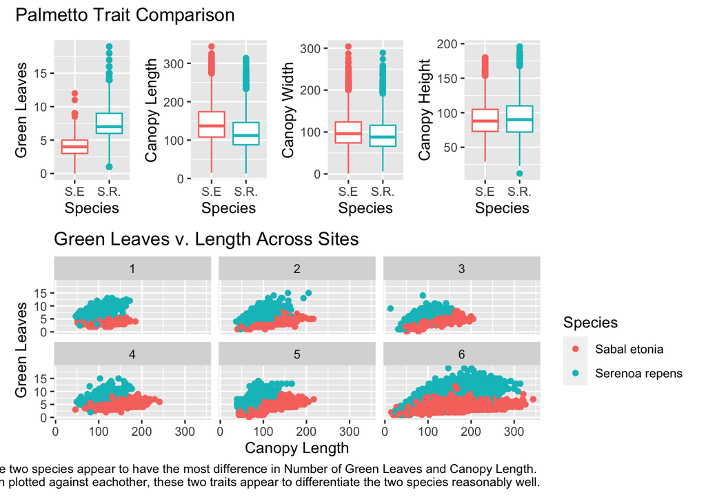

```r
cap <- 'The two species appear to have the most difference in Number of Green Leaves and Canopy Length. \nWhen plotted against eachother, these two traits appear to differentiate the two species reasonably well.'

p1 <- ggplot(data=palmetto, aes(x=species_short, y=green_lvs))+
  labs(x='Species',y='Green Leaves')+
  theme(legend.position = "none")+
  geom_boxplot(aes(color=species_short))

p2 <- ggplot(data=palmetto, aes(x=species_short, y=length))+
  labs(x='Species',y='Canopy Length')+
  theme(legend.position = "none")+
  geom_boxplot(aes(color=species_short))

p3 <- ggplot(data=palmetto, aes(x=species_short, y=width))+
  labs(x='Species',y='Canopy Width')+
  theme(legend.position = "none")+
  geom_boxplot(aes(color=species_short))

p4 <- ggplot(data=palmetto, aes(x=species_short, y=height))+
  labs(x='Species',y='Canopy Height')+
  theme(legend.position = "none")+
  geom_boxplot(aes(color=species_short))

p5 <- ggplot(data=palmetto, aes(x=length, y=green_lvs))+
  labs(title='Green Leaves v. Length Across Sites',x='Canopy Length',y='Green Leaves',color='Species',caption=cap)+
  geom_point(aes(color=species_name))+
  facet_wrap(~site)

patchplot <- (p1|p2|p3|p4)/p5 + plot_annotation(title='Palmetto Trait Comparison')
patchplot
```

### Binary Logistic Regression

```r
# Select only relevant columns for modeling & drop na
palmetto_mod <- palmetto_data %>%
  select(species_name, site, height, length, width, green_lvs ) %>%
  drop_na()
```

1. Log odds of plant type using plant height, canopy length, canopy width and green leaves as predictor variable.

```r
# Formula 1:
f1 <- species_name ~ height+length+width+green_lvs

# Generate Log Likelihood model 1:
palmetto_blr1 <- glm(formula = f1,
                      data=palmetto_mod,
                      family='binomial')

summary(palmetto_blr1)
```

```
##
## Call:
## glm(formula = f1, family = "binomial", data = palmetto_mod)
##
## Deviance Residuals:
##     Min       1Q   Median       3Q      Max
## -4.7828  -0.2681  -0.0054   0.1725   3.3964
##
## Coefficients:
##              Estimate Std. Error z value Pr(>|z|)
## (Intercept) -3.226685   0.142071  -22.71   <2e-16 ***
## height       0.029217   0.002306   12.67   <2e-16 ***
## length      -0.045823   0.001866  -24.56   <2e-16 ***
## width       -0.039443   0.002100  -18.78   <2e-16 ***
## green_lvs    1.908475   0.038863   49.11   <2e-16 ***
## ---
## Signif. codes:  0 '***' 0.001 '**' 0.01 '*' 0.05 '.' 0.1 ' ' 1
##
## (Dispersion parameter for binomial family taken to be 1)
##
##     Null deviance: 17005.5  on 12266  degrees of freedom
## Residual deviance:  5184.6  on 12262  degrees of freedom
## AIC: 5194.6
##
## Number of Fisher Scoring iterations: 7
```

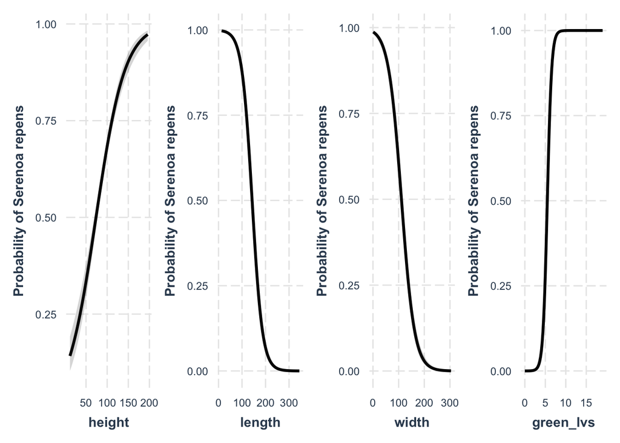

```r
# Plot model 1 probabilities by variable:

p11 <- effect_plot(palmetto_blr1,
            pred=height,
            interval=TRUE,
            y.label='Probability of Serenoa repens')
p12 <- effect_plot(palmetto_blr1,
            pred=length,
            interval=TRUE,
            y.label='Probability of Serenoa repens')
p13 <- effect_plot(palmetto_blr1,
            pred=width,
            interval=TRUE,
            y.label='Probability of Serenoa repens')
p14 <- effect_plot(palmetto_blr1,
            pred=green_lvs,
            interval=TRUE,
            y.label='Probability of Serenoa repens')

model1_plot <- (p11|p12|p13|p14)
model1_plot
```

2. Log odds of plant type using plant height, canopy width and green leaves (i.e., drop canopy length for this model)

```r
# Formula 2:
f2 <- species_name ~ height+width+green_lvs

# Generate Log Likelihood model 2:
palmetto_blr2 <- glm(formula = f2,
                      data=palmetto_mod,
                      family='binomial')

summary(palmetto_blr2)
```

```
##
## Call:
## glm(formula = f2, family = "binomial", data = palmetto_mod)
##
## Deviance Residuals:
##     Min       1Q   Median       3Q      Max
## -4.7113  -0.3404  -0.0112   0.2167   3.4455
##
## Coefficients:
##              Estimate Std. Error z value Pr(>|z|)
## (Intercept) -3.767722   0.135314 -27.844   <2e-16 ***
## height       0.002950   0.001881   1.568    0.117
## width       -0.069019   0.001785 -38.661   <2e-16 ***
## green_lvs    1.884815   0.036127  52.172   <2e-16 ***
## ---
## Signif. codes:  0 '***' 0.001 '**' 0.01 '*' 0.05 '.' 0.1 ' ' 1
##
## (Dispersion parameter for binomial family taken to be 1)
##
##     Null deviance: 17005.5  on 12266  degrees of freedom
## Residual deviance:  5979.5  on 12263  degrees of freedom
## AIC: 5987.5
##
## Number of Fisher Scoring iterations: 7
```

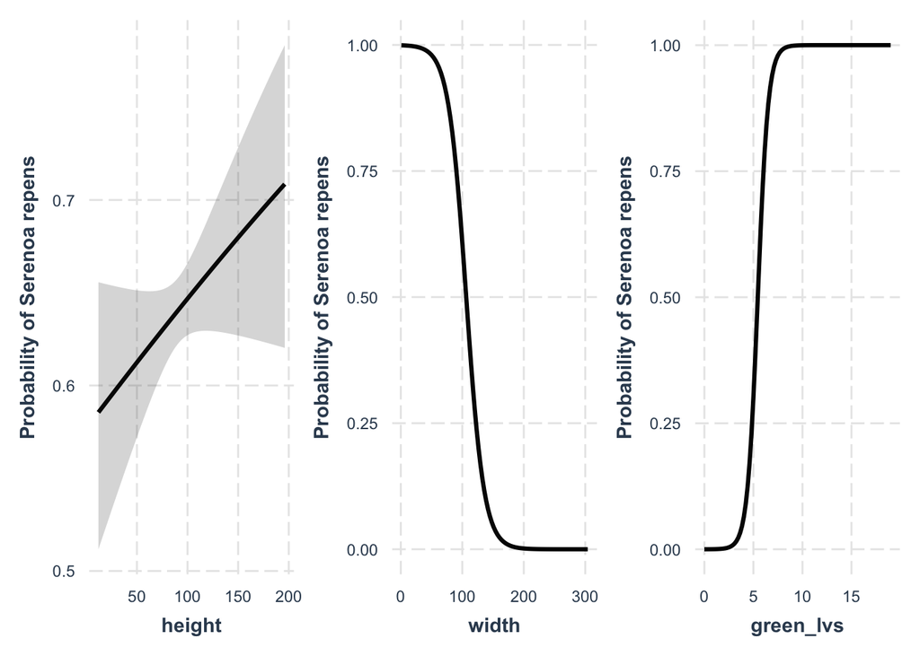

```r
p21 <- effect_plot(palmetto_blr2,
            pred=height,
            interval=TRUE,
            y.label='Probability of Serenoa repens')
p23 <- effect_plot(palmetto_blr2,
            pred=width,
            interval=TRUE,
            y.label='Probability of Serenoa repens')
p24 <- effect_plot(palmetto_blr2,
            pred=green_lvs,
            interval=TRUE,
            y.label='Probability of Serenoa repens')

model1_plot <- (p21|p23|p24)
model1_plot
```

### Model Evaluation

##### Model 1 is the better model, delta AIC >> 2. 10 fold cross validation also reports a higher accuracy for model 1.

AIC Values:

```r
AICcmodavg::aictab(list(palmetto_blr1,palmetto_blr2))
```

```
##
## Model selection based on AICc:
##
##      K    AICc Delta_AICc AICcWt Cum.Wt       LL
## Mod1 5 5194.57       0.00      1      1 -2592.28
## Mod2 4 5987.48     792.91      0      1 -2989.74
```

10-Fold Cross Validation, use prediction accuracy to evaluate:

```r
# Use caret package to automate:

set.seed(142)
tr_ctrl <- trainControl(method='repeatedcv',number=10,repeats=10)

# Train the models:
model1 <- train(f1, data=palmetto_mod,
                method='glm',
                family='binomial',
                trControl=tr_ctrl)

model2 <- train(f2, data=palmetto_mod,
                method='glm',
                family='binomial',
                trControl=tr_ctrl)
```

```r
model1
```

```
## Generalized Linear Model
##
## 12267 samples
##     4 predictor
##     2 classes: 'Sabal etonia', 'Serenoa repens'
##
## No pre-processing
## Resampling: Cross-Validated (10 fold, repeated 10 times)
## Summary of sample sizes: 11041, 11041, 11039, 11040, 11040, 11040, ...
## Resampling results:
##
##   Accuracy   Kappa
##   0.9168175  0.8336226
```

```r
model2
```

```
## Generalized Linear Model
##
## 12267 samples
##     3 predictor
##     2 classes: 'Sabal etonia', 'Serenoa repens'
##
## No pre-processing
## Resampling: Cross-Validated (10 fold, repeated 10 times)
## Summary of sample sizes: 11040, 11040, 11041, 11039, 11040, 11041, ...
## Resampling results:
##
##   Accuracy   Kappa
##   0.8988826  0.797747
```

### Train Model 1 (final model) over whole data set:

```r
palm_model <- glm(formula = f1,
                  data=palmetto_mod,
                  family='binomial')

palm_model_tidy <- broom::tidy(palm_model)
palm_model_tidy
```

```
## # A tibble: 5 × 5
##   term        estimate std.error statistic   p.value
##   <chr>          <dbl>     <dbl>     <dbl>     <dbl>
## 1 (Intercept)  -3.23     0.142       -22.7 3.42e-114
## 2 height        0.0292   0.00231      12.7 8.69e- 37
## 3 length       -0.0458   0.00187     -24.6 3.73e-133
## 4 width        -0.0394   0.00210     -18.8 1.05e- 78
## 5 green_lvs     1.91     0.0389       49.1 0
```

### How successfully final model evaluates a palm as the correct species:

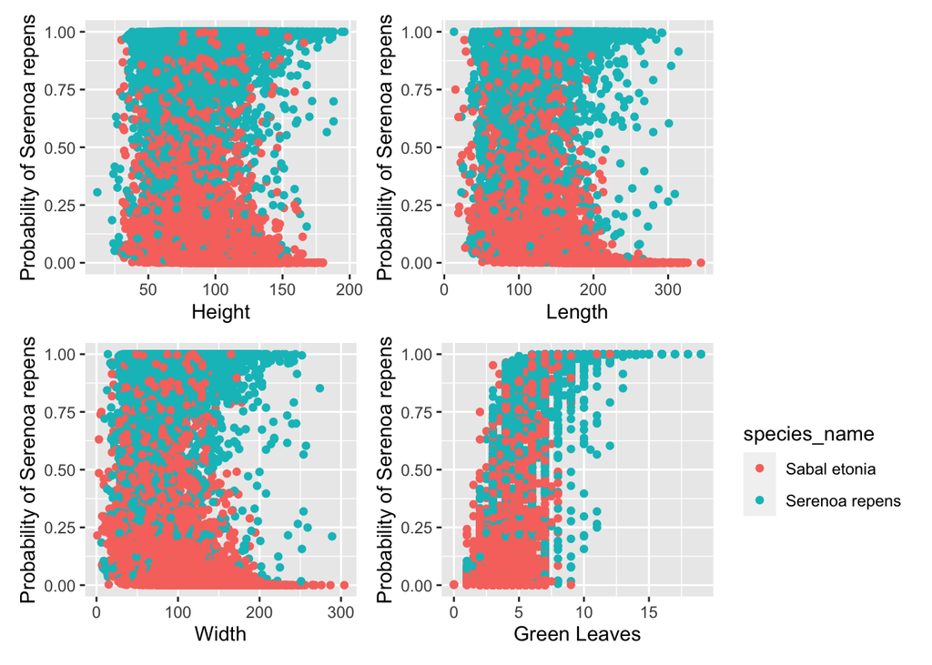

```r
# Convert log odds into probability, see palm_model_fitted: '.fitted'

palm_model_fitted <- palm_model %>%
  broom::augment(type.predict='response')


p31 <- ggplot(data=palm_model_fitted, aes(x=height, y=.fitted))+
  geom_point(aes(color=species_name))+
  theme(legend.position = "none")+
  labs(x='Height', y='Probability of Serenoa repens')
p32 <- ggplot(data=palm_model_fitted, aes(x=length, y=.fitted))+
  geom_point(aes(color=species_name))+
  theme(legend.position = "none")+
  labs(x='Length', y='Probability of Serenoa repens')
p33 <- ggplot(data=palm_model_fitted, aes(x=width, y=.fitted))+
  geom_point(aes(color=species_name))+
  theme(legend.position = "none")+
  labs(x='Width', y='Probability of Serenoa repens')
p34 <- ggplot(data=palm_model_fitted, aes(x=green_lvs, y=.fitted))+
  geom_point(aes(color=species_name))+
  labs(x='Green Leaves', y='Probability of Serenoa repens')

palm_model_plot <- (p31|p32)/(p33|p34)
palm_model_plot
```

```r
palm_model_fitted
```

```
## # A tibble: 12,267 × 11
##    species_name height length width green_lvs .fitted  .resid .std.resid    .hat
##    <fct>         <int>  <int> <int>     <dbl>   <dbl>   <dbl>      <dbl>   <dbl>
##  1 Serenoa rep…     51     69    63         6 0.983    0.184      0.184  1.91e-4
##  2 Sabal etonia     79    129    71         3 0.0197  -0.200     -0.200  1.51e-4
##  3 Serenoa rep…     80     90    66         6 0.979    0.207      0.207  1.65e-4
##  4 Sabal etonia     59     80    72         2 0.0149  -0.173     -0.173  1.51e-4
##  5 Serenoa rep…     83     96    79         6 0.958    0.292      0.292  2.32e-4
##  6 Sabal etonia     93    119    90         2 0.00335 -0.0819    -0.0819 4.94e-5
##  7 Serenoa rep…     50     49    40         6 0.997    0.0754     0.0754 5.23e-5
##  8 Sabal etonia     79     94    68         2 0.0164  -0.182     -0.182  1.40e-4
##  9 Serenoa rep…     66     70    70         5 0.907    0.442      0.442  4.80e-4
## 10 Sabal etonia     57     92    70         3 0.0566  -0.342     -0.342  2.89e-4
## # … with 12,257 more rows, and 2 more variables: .sigma <dbl>, .cooksd <dbl>
```

```r
# Add a column that classifies species by 50% probability:
palm_model_fitted_class <- palm_model_fitted %>%
  mutate(classify=case_when(
    .fitted>=0.5~'Serenoa repens',
    .fitted<0.5~'Sabal etonia'))

# Add a column that evaluating accuracy:
palm_model_fitted_ac <- palm_model_fitted_class %>%
  mutate(accuracy=case_when(
    species_name=='Serenoa repens' & classify=='Serenoa repens'~1,
    species_name=='Serenoa repens' & classify=='Sabal etonia'~-1,
    species_name=='Sabal etonia' & classify=='Serenoa repens'~-2,
    species_name=='Sabal etonia' & classify=='Sabal etonia'~2))

# Count correctly and incorrectly identified palmettos, calculate % correct:
sr_y <- length(which(palm_model_fitted_ac$accuracy==1))
sr_n <- length(which(palm_model_fitted_ac$accuracy==-1))
se_y <- length(which(palm_model_fitted_ac$accuracy==2))
se_n <- length(which(palm_model_fitted_ac$accuracy==-2))
sr_perc <- round(sr_y/(sr_y+sr_n),2)
se_perc <- round(se_y/(se_y+se_n),2)

spec <-c('Serenoa repens','Sabal etonia')
correct <- c(sr_y,se_y)
incorrect <- c(sr_n,se_n)
percent_correct <- c(sr_perc,se_perc)

final_df <- data.frame(spec,correct,incorrect,percent_correct)
```

```r
# Final Table:
cols<-c('Species','Correct','Incorrect','% Correct')
kable(final_df, col.names=cols, caption='Model 1 Performance Summary')
```

Model 1 Performance Summary

| Species | Correct | Incorrect | % Correct |
| --- | --- | --- | --- |
| Serenoa repens | 5548 | 564 | 0.91 |
| Sabal etonia | 5701 | 454 | 0.93 |

Model 1 correctly identifies both species at a frequency > 90%. It is slightly better at identifying *Sabal etonia* than *Serenoa repens*.